# PWA GAP ANALYSIS - Technical Report

- **Created by Kevin Muhia Gathogo**
- **Created on Jul 29, 2021**
- **Runned on Mar 25, 2022** (`feature.shape, Gives Current (x, y) x -total rows/features and y the current fields`)

This is a gap analysis of ROADS_Asbuilt Dataset, EGIS SDE 64.

## Roads_Asbuilts

Under Roads Asbuilt, we have three feature classes.

```
•   Carriageway
•   Road_Level
•   Road_Line
```

The report captures the total count of empty or null columns or unfilled attributes per each asset.

The unfilled attributes are highlighted in a summarised numerical count and visualised using bar graphs.

```python
#Importing the relevent modules
import pandas as pd
from arcgis import GIS
import matplotlib.pyplot as plt
%matplotlib inline
```

### 1. Carriageway

Carriageway feature class has:

```
    •   Attribute Fields (Columns): 54
    •   Total Records (Rows): 235,820
```

Below is a representation of null values for each attribute field

```python
#Viewing the first two attribute records of the feaure class.
Carriageway = pd.DataFrame.spatial.from_featureclass(r"C:\Users\esd_kgathogo\AppData\Roaming\ESRI\Desktop10.7\ArcCatalog\PWAROADS.sde\SDE.ROADS\SDE.Carriageway")
Carriageway.head(2)
```

|  | OBJECTID | GFCODE | FEATURE_NAME | PROJECT_CODE | PROJECT_STATUS | PROJECT_TYPE | RD_ANAME | RD_ENAME | STREET_NO | ZONE_NO | FEATURE_REMARKS | SOURCE_DATA_INPUT_FORMAT | DATA_INPUT_METHOD | METADATA | SOURCE_DEPT_SECTION_UNIT | OWNER | DATE_CREATED | EDITED_BY | LAST_UPDATED_DATE | BUSINESS_APPROVAL_BY | BUSINESS_APPROVAL_DATE | CONDITIONAL_DATA_APPROVAL_BY | CONDITIONAL_DATA_APPROVAL_DATE | DATA_QC_APPROVAL_BY | DATA_QC_APPROVAL_DATE | COST_PER_ITEM_METER | STOCK_ON_HAND | AGENCY_NAME | DMS_CODE | … |
| --- | --- | --- | --- | --- | --- | --- | --- | --- | --- | --- | --- | --- | --- | --- | --- | --- | --- | --- | --- | --- | --- | --- | --- | --- | --- | --- | --- | --- | --- | --- |
| 0 | 96701 | None | 13.0 | SRPMT_2010_07 | As Built | New | طريق سلوى | Salwa Road | 340.0 | 56.0 | None | DWG | Data Conversion | None | PDS | None | 2013-04-18 | Arif | NaT | None | NaT | None | NaT | None | NaT | NaN | NaN | Ashghal | None | … |
| 1 | 95019 | None | 24.0 | ERC0638C1B | As Built | New | طريق الشمال | Al Shamal Road | 253.0 | 74.0 | Contract 2 | DWG | Data Conversion | Yes | Roads Projects | Infrastructure Affairs | 2014-07-15 | Lateef | NaT | None | NaT | None | NaT | None | NaT | NaN | NaN | Ashghal | None | … |

```python
#359,777 indicate the number of records, 54 indicates the total columns or attribute fields of the feature class.
#It differs from 235,820 above since its live data.Updation has been done as of today Mar 25,2022.
#Useful also to track work progress.Once the code is re-run it captures the current data.
Carriageway.shape
```

```
(359777, 54)
```

```python
Carriageway_null_values = pd.DataFrame(Carriageway.isnull().sum())
```

```python
#List of attribute fields corresponding to the count of empty/unfilled/null.
Carriageway_null_values
```

|  | 0 |
| --- | --- |
| OBJECTID | 0 |
| GFCODE | 45159 |
| FEATURE_NAME | 261 |
| PROJECT_CODE | 1330 |
| PROJECT_STATUS | 3365 |
| PROJECT_TYPE | 195384 |
| RD_ANAME | 138156 |
| RD_ENAME | 32781 |
| STREET_NO | 20276 |
| ZONE_NO | 3718 |
| FEATURE_REMARKS | 283270 |
| SOURCE_DATA_INPUT_FORMAT | 8529 |
| DATA_INPUT_METHOD | 27475 |
| METADATA | 231265 |
| SOURCE_DEPT_SECTION_UNIT | 199434 |
| OWNER | 100936 |
| DATE_CREATED | 16453 |
| EDITED_BY | 519 |
| LAST_UPDATED_DATE | 111314 |
| BUSINESS_APPROVAL_BY | 343910 |
| BUSINESS_APPROVAL_DATE | 359434 |
| CONDITIONAL_DATA_APPROVAL_BY | 346231 |
| CONDITIONAL_DATA_APPROVAL_DATE | 359434 |
| DATA_QC_APPROVAL_BY | 309548 |
| DATA_QC_APPROVAL_DATE | 324217 |
| COST_PER_ITEM_METER | 357563 |
| STOCK_ON_HAND | 357523 |
| AGENCY_NAME | 1130 |
| DMS_CODE | 344703 |
| RESERVED_FOR_FUTURE | 336958 |
| ROAD_TYPE | 194889 |
| ROAD_CLASS | 196423 |
| ROAD_CROSSING_ZONE_NO | 332795 |
| LANE_ID | 351254 |
| PAVEMENT_TYPE | 290981 |
| PAVMENT_CONDITION | 257819 |
| SYMBOLOGY | 353982 |
| FEATURE_LEVEL | 6764 |
| HEIGHT | 357256 |
| FEATURE_NAME_DM | 163633 |
| GLOBALID | 42882 |
| FEATURE_STATUS | 9576 |
| SURVEY_REF | 357226 |
| PROJ_REF | 136962 |
| LANE_RIGHT | 359777 |
| LANE_LEFT | 359777 |
| GLOBALID_1 | 0 |
| CREATED_USER | 87872 |
| CREATED_DATE | 87872 |
| LAST_EDITED_USER | 718 |
| LAST_EDITED_DATE | 718 |
| LANE_NUMBER | 349442 |
| MATERIAL | 334858 |
| SHAPE | 274 |

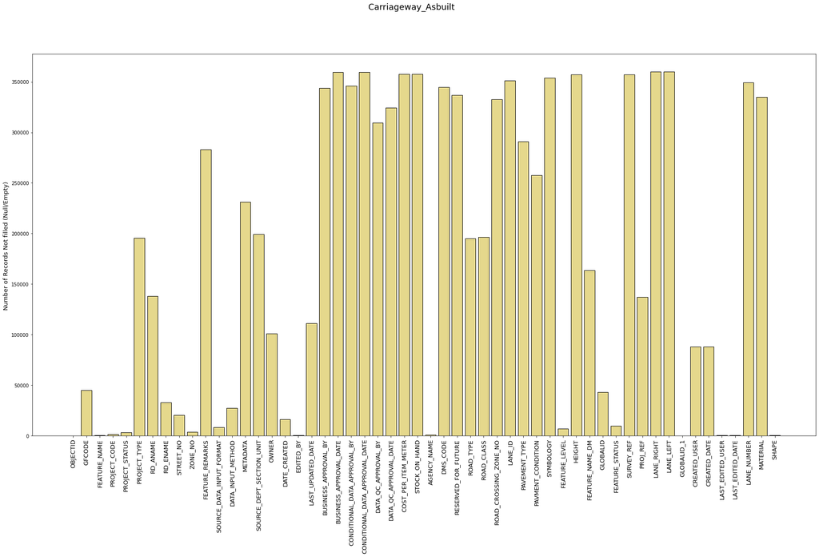

```python
#visualising the quantity of nulls per attribute fields.
x = Carriageway.columns
y = Carriageway.isnull().sum()

plt.figure(figsize=(30,15))
plt.bar(x, y, color= (0.8,0.7,0.1,0.5),  edgecolor='Black')
plt.suptitle("Carriageway_Asbuilt", fontsize=18)
plt.ylabel("Number of Records Not filled (Null/Empty) ", fontsize=13)
plt.xticks(rotation=90, fontsize=13)
plt.show()
```

### 2. Road Lines

Road_Lines feature class has:

```
    •   Attribute Fields (Columns): 43
    •   Total Records (Rows): 835,676
```

Below is a representation of null values for each attribute field

```python
Road_Lines = pd.DataFrame.spatial.from_featureclass(r"C:\Users\esd_kgathogo\AppData\Roaming\ESRI\Desktop10.7\ArcCatalog\PWAROADS.sde\SDE.ROADS\SDE.Road_Lines")
Road_Lines.head(2)
```

|  | OBJECTID | GFCODE | FEATURE_NAME | PROJECT_CODE | PROJECT_STATUS | PROJECT_TYPE | RD_ANAME | RD_ENAME | STREET_NO | ZONE_NO | FEATURE_REMARKS | SOURCE_DATA_INPUT_FORMAT | DATA_INPUT_METHOD | METADATA | SOURCE_DEPT_SECTION_UNIT | OWNER | DATE_CREATED | EDITED_BY | LAST_UPDATED_DATE | BUSINESS_APPROVAL_BY | BUSINESS_APPROVAL_DATE | CONDITIONAL_DATA_APPROVAL_BY | CONDITIONAL_DATA_APPROVAL_DATE | DATA_QC_APPROVAL_BY | DATA_QC_APPROVAL_DATE | COST_PER_ITEM_METER | STOCK_ON_HAND | AGENCY_NAME | DMS_CODE | … |
| --- | --- | --- | --- | --- | --- | --- | --- | --- | --- | --- | --- | --- | --- | --- | --- | --- | --- | --- | --- | --- | --- | --- | --- | --- | --- | --- | --- | --- | --- | --- |
| 0 | 225 | None | 11.0 | ERC0638D2 | As Built | None | دخان | Dukhan | 373.0 | 72.0 | None | DWG | Data Conversion | None | Roads Projects | None | 2010-09-19 | Rao | NaT | None | None | None | None | None | None | NaN | NaN | Ashghal | None | … |
| 1 | 29 | None | 10.0 | ERC0638D2 | As Built | None | الشحانية | Al Shahhaniya | 800.0 | 72.0 | None | DWG | Data Conversion | None | Roads Projects | None | 2010-09-19 | Rao | NaT | None | None | None | None | None | None | NaN | NaN | Ashghal | None | … |

```python
#it differs from 835,676 above since its live data.There is continous updation, once the code is re-run it captures the current data.
Road_Lines.shape
```

```
(1672856, 43)
```

```python
Road_Lines_null = pd.DataFrame(Road_Lines.isnull().sum())
Road_Lines_null
```

|  | 0 |
| --- | --- |
| OBJECTID | 0 |
| GFCODE | 582000 |
| FEATURE_NAME | 249 |
| PROJECT_CODE | 2707 |
| PROJECT_STATUS | 24674 |
| PROJECT_TYPE | 771915 |
| RD_ANAME | 429489 |
| RD_ENAME | 147098 |
| STREET_NO | 68322 |
| ZONE_NO | 31275 |
| FEATURE_REMARKS | 823030 |
| SOURCE_DATA_INPUT_FORMAT | 121667 |
| DATA_INPUT_METHOD | 325682 |
| METADATA | 947059 |
| SOURCE_DEPT_SECTION_UNIT | 631598 |
| OWNER | 444896 |
| DATE_CREATED | 56138 |
| EDITED_BY | 36962 |
| LAST_UPDATED_DATE | 544404 |
| BUSINESS_APPROVAL_BY | 1473871 |
| BUSINESS_APPROVAL_DATE | 1669302 |
| CONDITIONAL_DATA_APPROVAL_BY | 1476272 |
| CONDITIONAL_DATA_APPROVAL_DATE | 1669302 |
| DATA_QC_APPROVAL_BY | 1448677 |
| DATA_QC_APPROVAL_DATE | 1645326 |
| COST_PER_ITEM_METER | 1668900 |
| STOCK_ON_HAND | 1668908 |
| AGENCY_NAME | 176455 |
| DMS_CODE | 1471396 |
| RESERVED_FOR_FUTURE | 1463149 |
| FEATURE_LEVEL | 684906 |
| HEIGHT | 1659922 |
| FEATURE_NAME_DM | 442931 |
| FEATURE_SPECIFICATION | 1475953 |
| FEATURE_STATUS | 605369 |
| SURVEY_REF | 1659903 |
| GLOBALID | 0 |
| PROJ_REF | 751194 |
| CREATED_USER | 1113962 |
| CREATED_DATE | 1113962 |
| LAST_EDITED_USER | 1109814 |
| LAST_EDITED_DATE | 1109814 |
| SHAPE | 535 |

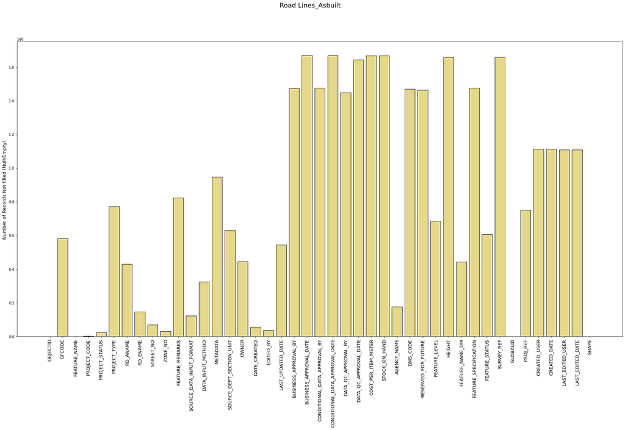

```python
x = Road_Lines.columns
y = Road_Lines.isnull().sum()
plt.figure(figsize=(30,15))
plt.bar(x, y, color= (0.8,0.7,0.1,0.5),  edgecolor='Black')
plt.suptitle("Road Lines_Asbuilt", fontsize=18)
plt.ylabel("Number of Records Not filled (Null/Empty) ", fontsize=13)
plt.xticks(rotation=90, fontsize=13)
plt.show()
```

### 3. Road Level

Road_Level feature class has:

```
    •   Attribute Fields (Columns): 43
    •   Total Records (Rows): 1,970,797
```

```python
Road_Level = pd.DataFrame.spatial.from_featureclass(r"C:\Users\esd_kgathogo\AppData\Roaming\ESRI\Desktop10.7\ArcCatalog\PWAROADS.sde\SDE.ROADS\SDE.Road_Level")
Road_Level.head(2)
```

|  | OBJECTID | GFCODE | FEATURE_NAME | PROJECT_CODE | PROJECT_STATUS | PROJECT_TYPE | RD_ANAME | RD_ENAME | STREET_NO | ZONE_NO | FEATURE_REMARKS | SOURCE_DATA_INPUT_FORMAT | DATA_INPUT_METHOD | METADATA | SOURCE_DEPT_SECTION_UNIT | OWNER | DATE_CREATED | EDITED_BY | LAST_UPDATED_DATE | BUSINESS_APPROVAL_BY | BUSINESS_APPROVAL_DATE | CONDITIONAL_DATA_APPROVAL_BY | CONDITIONAL_DATA_APPROVAL_DATE | DATA_QC_APPROVAL_BY | DATA_QC_APPROVAL_DATE | COST_PER_ITEM_METER | STOCK_ON_HAND | AGENCY_NAME | DMS_CODE | … |
| --- | --- | --- | --- | --- | --- | --- | --- | --- | --- | --- | --- | --- | --- | --- | --- | --- | --- | --- | --- | --- | --- | --- | --- | --- | --- | --- | --- | --- | --- | --- |
| 0 | 694618 | RDNDRLVL | Ground Level | None | As Built | None | None | None | NaN | NaN | Expressway | DWG | Data Conversion | None | PMC | None | 2016-12-29 | Arif | 2017-01-02 | None | None | None | None | None | None | None | None | Ashghal | None | … |
| 1 | 694544 | RDNDRLVL | Ground Level | None | As Built | None | None | None | NaN | NaN | Expressway | DWG | Data Conversion | None | PMC | None | 2016-12-29 | Arif | 2017-01-02 | None | None | None | None | None | None | None | None | Ashghal | None | … |

```python
Road_Level.shape
```

```
(3099258, 43)
```

```python
Road_Level_null = pd.DataFrame(Road_Level.isnull().sum())
Road_Level_null
```

|  | 0 |
| --- | --- |
| OBJECTID | 0 |
| GFCODE | 1 |
| FEATURE_NAME | 17711 |
| PROJECT_CODE | 348911 |
| PROJECT_STATUS | 242 |
| PROJECT_TYPE | 1568776 |
| RD_ANAME | 1488712 |
| RD_ENAME | 921545 |
| STREET_NO | 853357 |
| ZONE_NO | 653756 |
| FEATURE_REMARKS | 2149766 |
| SOURCE_DATA_INPUT_FORMAT | 409904 |
| DATA_INPUT_METHOD | 655479 |
| METADATA | 2044426 |
| SOURCE_DEPT_SECTION_UNIT | 1281092 |
| OWNER | 1008827 |
| DATE_CREATED | 230323 |
| EDITED_BY | 25718 |
| LAST_UPDATED_DATE | 790890 |
| BUSINESS_APPROVAL_BY | 2965103 |
| BUSINESS_APPROVAL_DATE | 3099258 |
| CONDITIONAL_DATA_APPROVAL_BY | 3033285 |
| CONDITIONAL_DATA_APPROVAL_DATE | 3099258 |
| DATA_QC_APPROVAL_BY | 2776801 |
| DATA_QC_APPROVAL_DATE | 2988849 |
| COST_PER_ITEM_METER | 3099258 |
| STOCK_ON_HAND | 3098301 |
| AGENCY_NAME | 776000 |
| DMS_CODE | 2689883 |
| ELEVATION | 20045 |
| FEATURE_LEVEL | 1069773 |
| HEIGHT | 2768406 |
| EASTING | 1698608 |
| NORTHING | 1649790 |
| FEATURE_STATUS | 1731939 |
| SURVEY_REF | 3058348 |
| PROJ_REF | 1401838 |
| GLOBALID | 0 |
| CREATED_USER | 551237 |
| CREATED_DATE | 551237 |
| LAST_EDITED_USER | 0 |
| LAST_EDITED_DATE | 0 |
| SHAPE | 0 |

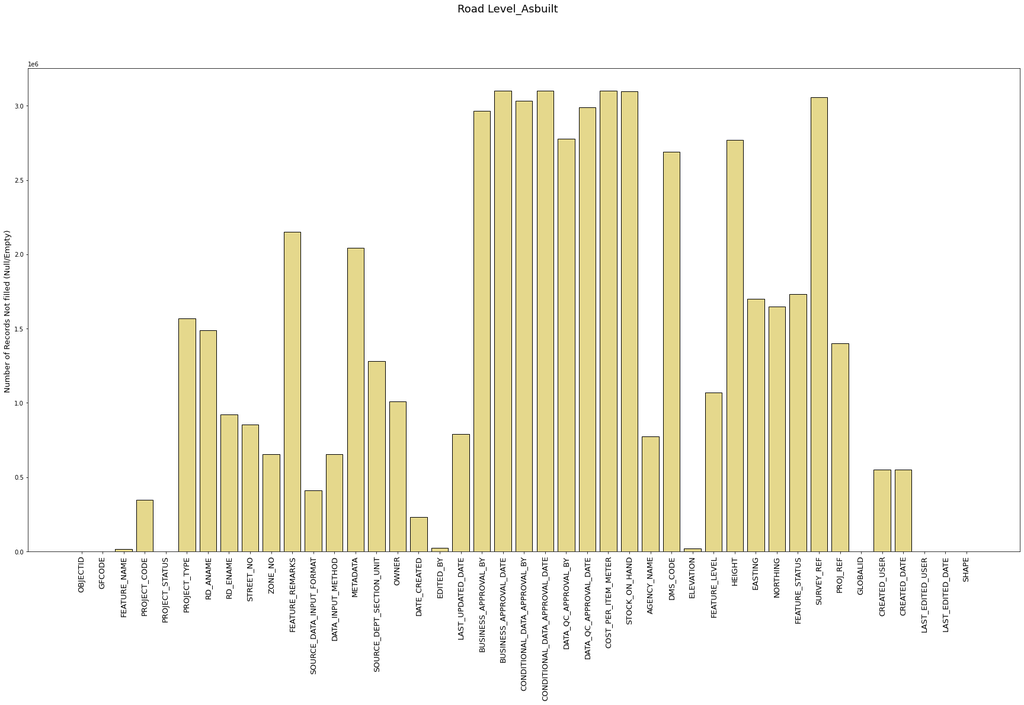

```python
x = Road_Level.columns
y = Road_Level.isnull().sum()
plt.figure(figsize=(30,15))
plt.bar(x, y, color= (0.8,0.7,0.1,0.5),  edgecolor='Black')
plt.suptitle("Road Level_Asbuilt", fontsize=18)
plt.ylabel("Number of Records Not filled (Null/Empty) ", fontsize=13)
plt.xticks(rotation=90, fontsize=13)
plt.show()
```

## Traffic Safety

Insight on the 15 feature classes under traffic safety Asbuilt dataset.

```
•   Road marking Line
•   Road Marking Polygon
•   Traffic sign
•   Traffic signal Pole
•   Traffic signal Duct
•   Control Box
•   Detector Loop
•   Inspection Chamber
•   Phasing
•   Studs
•   Traf_Junct_RA
•   Traffic Bollard
•   Traffic Signal Connections
•   Traffic Signal Junction
•   Traffic Signal Junction old
```

### 1. Road_Marking Lines

Road Marking Line feature class has:

```
    •   Attribute Fields (Columns): 44
    •   Total Records (Rows): 260,477
```

```python
Road_Marking_Lines = pd.DataFrame.spatial.from_featureclass(r"C:\Users\esd_kgathogo\AppData\Roaming\ESRI\Desktop10.7\ArcCatalog\PWAROADS.sde\SDE.TRAFFIC_SAFETY\SDE.Road_Marking_Lines")
Road_Marking_Lines.head(2)
```

|  | OBJECTID | GFCODE | FEATURE_NAME | PROJECT_CODE | PROJECT_STATUS | PROJECT_TYPE | RD_ANAME | RD_ENAME | STREET_NO | ZONE_NO | FEATURE_REMARKS | SOURCE_DATA_INPUT_FORMAT | DATA_INPUT_METHOD | METADATA | SOURCE_DEPT_SECTION_UNIT | OWNER | DATE_CREATED | EDITED_BY | LAST_UPDATED_DATE | BUSINESS_APPROVAL_BY | BUSINESS_APPROVAL_DATE | CONDITIONAL_DATA_APPROVAL_BY | CONDITIONAL_DATA_APPROVAL_DATE | DATA_QC_APPROVAL_BY | DATA_QC_APPROVAL_DATE | COST_PER_ITEM_METER | STOCK_ON_HAND | AGENCY_NAME | DMS_CODE | … |
| --- | --- | --- | --- | --- | --- | --- | --- | --- | --- | --- | --- | --- | --- | --- | --- | --- | --- | --- | --- | --- | --- | --- | --- | --- | --- | --- | --- | --- | --- | --- |
| 0 | 135484 | RDLNRDML | RD_MRK_LINE_507 | DS126 | As Built | RIW | نجمة | Najma | 320.0 | 42.0 | None | DWG | Data Conversion | None | PDS | None | 2015-11-02 | Eric | NaT | None | None | None | None | None | NaT | NaN | NaN | Ashghal | None | … |
| 1 | 137623 | RDLNRDML | RD_MRK_LINE_513 | DS126 | As Built | RIW | نجمة | Najma | 320.0 | 42.0 | None | DWG | Data Conversion | None | PDS | None | 2015-11-02 | Eric | NaT | None | None | None | None | None | NaT | NaN | NaN | Ashghal | None | … |

```python
Road_Marking_Lines.shape
```

```
(303160, 44)
```

```python
Road_Marking_Lines_null = pd.DataFrame(Road_Marking_Lines.isnull().sum())
Road_Marking_Lines_null
```

|  | 0 |
| --- | --- |
| OBJECTID | 0 |
| GFCODE | 708 |
| FEATURE_NAME | 682 |
| PROJECT_CODE | 105 |
| PROJECT_STATUS | 2293 |
| PROJECT_TYPE | 137465 |
| RD_ANAME | 76245 |
| RD_ENAME | 50791 |
| STREET_NO | 41895 |
| ZONE_NO | 27274 |
| FEATURE_REMARKS | 237443 |
| SOURCE_DATA_INPUT_FORMAT | 8386 |
| DATA_INPUT_METHOD | 36944 |
| METADATA | 148420 |
| SOURCE_DEPT_SECTION_UNIT | 77317 |
| OWNER | 113715 |
| DATE_CREATED | 2895 |
| EDITED_BY | 1457 |
| LAST_UPDATED_DATE | 160496 |
| BUSINESS_APPROVAL_BY | 270489 |
| BUSINESS_APPROVAL_DATE | 303160 |
| CONDITIONAL_DATA_APPROVAL_BY | 279759 |
| CONDITIONAL_DATA_APPROVAL_DATE | 303160 |
| DATA_QC_APPROVAL_BY | 263873 |
| DATA_QC_APPROVAL_DATE | 289405 |
| COST_PER_ITEM_METER | 302447 |
| STOCK_ON_HAND | 302435 |
| AGENCY_NAME | 71802 |
| DMS_CODE | 271449 |
| ROAD_MARKING_CODE | 1617 |
| DESCRIPTION | 220710 |
| SPECIFICATIONS | 157103 |
| FEATURE_LEVEL | 92023 |
| FEATURE_HEIGHT | 297545 |
| FEATURE_STATUS | 55734 |
| SURVEY_REF | 303129 |
| GLOBALID | 0 |
| PROJ_REF | 170612 |
| CREATED_USER | 105943 |
| CREATED_DATE | 105943 |
| LAST_EDITED_USER | 108 |
| LAST_EDITED_DATE | 108 |
| SHAPE.LEN | 0 |
| SHAPE | 47 |

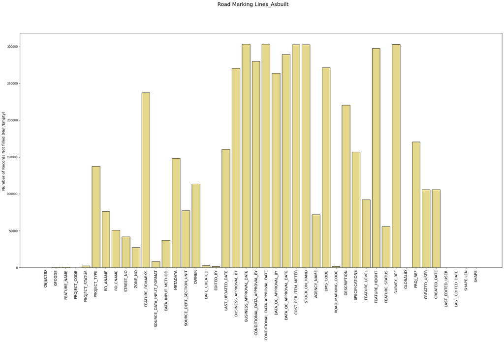

```python
x = Road_Marking_Lines.columns
y = Road_Marking_Lines.isnull().sum()
plt.figure(figsize=(30,15))
plt.bar(x, y, color= (0.8,0.7,0.1,0.5),  edgecolor='Black')
plt.suptitle("Road Marking Lines_Asbuilt", fontsize=18)
plt.ylabel("Number of Records Not filled (Null/Empty) ", fontsize=13)
plt.xticks(rotation=90, fontsize=13)
plt.show()
```

### 2. Road Marking Polygon

Road Marking Polygon feature class has:

```
    •   Attribute Fields (Columns): 43
    •   Total Records (Rows): 46,795
```

```python
Road_Marking_Polygon = pd.DataFrame.spatial.from_featureclass(r"C:\Users\esd_kgathogo\AppData\Roaming\ESRI\Desktop10.7\ArcCatalog\PWAROADS.sde\SDE.TRAFFIC_SAFETY\SDE.Road_Marking_Polygon")
Road_Marking_Polygon.head(2)
```

|  | OBJECTID | GFCODE | FEATURE_NAME | PROJECT_CODE | PROJECT_STATUS | PROJECT_TYPE | RD_ANAME | RD_ENAME | STREET_NO | ZONE_NO | FEATURE_REMARKS | SOURCE_DATA_INPUT_FORMAT | DATA_INPUT_METHOD | METADATA | SOURCE_DEPT_SECTION_UNIT | OWNER | DATE_CREATED | EDITED_BY | LAST_UPDATED_DATE | BUSINESS_APPROVAL_BY | BUSINESS_APPROVAL_DATE | CONDITIONAL_DATA_APPROVAL_BY | CONDITIONAL_DATA_APPROVAL_DATE | DATA_QC_APPROVAL_BY | DATA_QC_APPROVAL_DATE | COST_PER_ITEM_METER | STOCK_ON_HAND | AGENCY_NAME | DMS_CODE | … |
| --- | --- | --- | --- | --- | --- | --- | --- | --- | --- | --- | --- | --- | --- | --- | --- | --- | --- | --- | --- | --- | --- | --- | --- | --- | --- | --- | --- | --- | --- | --- |
| 0 | 94923 | RDARRDMP | Road Marking Polygon | IA 13/14 C 06 ST | As Built | New | None | None | NaN | 53.0 | None | None | None | None | None | None | 2018-08-15 | Nishin | 2019-03-28 | None | None | None | None | Arif | 2019-03-27 | NaN | NaN | Ashghal | None | … |
| 1 | 94924 | RDARRDMP | Road Marking Polygon | IA 13/14 C 06 ST | As Built | New | None | None | NaN | 53.0 | None | None | None | None | None | None | 2018-08-15 | Nishin | 2019-03-28 | None | None | None | None | Arif | 2019-03-27 | NaN | NaN | Ashghal | None | … |

```python
Road_Marking_Polygon.shape
```

```
(60468, 43)
```

```python
Road_Marking_Polygon_null = pd.DataFrame(Road_Marking_Polygon.isnull().sum())
Road_Marking_Polygon_null
```

|  | 0 |
| --- | --- |
| OBJECTID | 0 |
| GFCODE | 0 |
| FEATURE_NAME | 0 |
| PROJECT_CODE | 643 |
| PROJECT_STATUS | 746 |
| PROJECT_TYPE | 28788 |
| RD_ANAME | 17745 |
| RD_ENAME | 11269 |
| STREET_NO | 8442 |
| ZONE_NO | 11401 |
| FEATURE_REMARKS | 42858 |
| SOURCE_DATA_INPUT_FORMAT | 2141 |
| DATA_INPUT_METHOD | 8118 |
| METADATA | 34758 |
| SOURCE_DEPT_SECTION_UNIT | 19055 |
| OWNER | 23431 |
| DATE_CREATED | 2364 |
| EDITED_BY | 1988 |
| LAST_UPDATED_DATE | 23408 |
| BUSINESS_APPROVAL_BY | 50041 |
| BUSINESS_APPROVAL_DATE | 60468 |
| CONDITIONAL_DATA_APPROVAL_BY | 52004 |
| CONDITIONAL_DATA_APPROVAL_DATE | 60468 |
| DATA_QC_APPROVAL_BY | 47583 |
| DATA_QC_APPROVAL_DATE | 56499 |
| COST_PER_ITEM_METER | 60374 |
| STOCK_ON_HAND | 60362 |
| AGENCY_NAME | 12143 |
| DMS_CODE | 50788 |
| ROAD_MARKING_CODE | 1131 |
| DESCRIPTION | 37452 |
| SPECIFICATIONS | 25668 |
| FEATURE_LEVEL | 6910 |
| FEATURE_HEIGHT | 58764 |
| FEATURE_STATUS | 10444 |
| SURVEY_REF | 60435 |
| GLOBALID | 0 |
| PROJ_REF | 37528 |
| CREATED_USER | 60468 |
| CREATED_DATE | 60210 |
| LAST_EDITED_USER | 60468 |
| LAST_EDITED_DATE | 60210 |
| SHAPE | 22 |

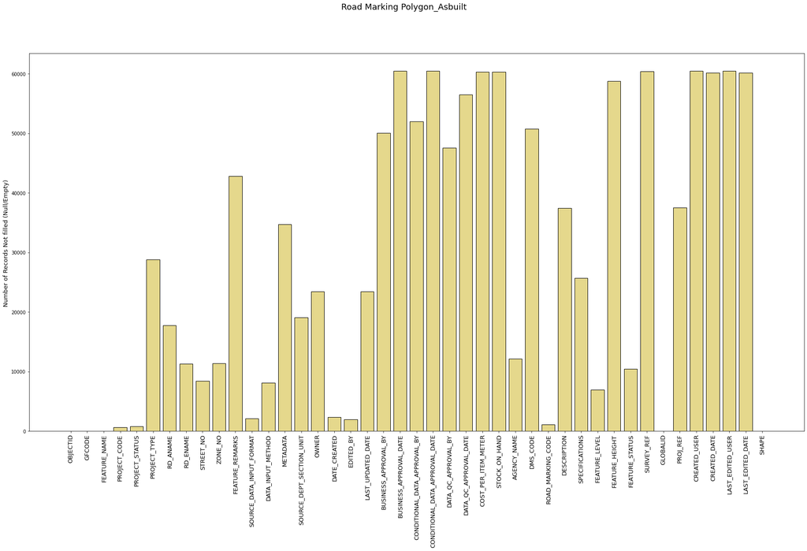

```python
x = Road_Marking_Polygon.columns
y = Road_Marking_Polygon.isnull().sum()
plt.figure(figsize=(30,15))
plt.bar(x, y, color= (0.8,0.7,0.1,0.5),  edgecolor='Black')
plt.suptitle("Road Marking Polygon_Asbuilt", fontsize=18)
plt.ylabel("Number of Records Not filled (Null/Empty) ", fontsize=13)
plt.xticks(rotation=90, fontsize=13)
plt.show()
```

### 3. Traffic Sign

Traffic Sign feature class has:

```
    •   Attribute Fields (Columns): 72
    •   Total Records (Rows): 48,773
```

```python
Traffic_Sign = pd.DataFrame.spatial.from_featureclass(r"C:\Users\esd_kgathogo\AppData\Roaming\ESRI\Desktop10.7\ArcCatalog\PWAROADS.sde\SDE.TRAFFIC_SAFETY\SDE.Traffic_Sign")
Traffic_Sign.head(2)
```

|  | OBJECTID | GFCODE | FEATURE_NAME | PROJECT_CODE | PROJECT_STATUS | PROJECT_TYPE | RD_ANAME | RD_ENAME | STREET_NO | ZONE_NO | FEATURE_REMARKS | SOURCE_DATA_INPUT_FORMAT | DATA_INPUT_METHOD | METADATA | SOURCE_DEPT_SECTION_UNIT | OWNER | DATE_CREATED | EDITED_BY | LAST_UPDATED_DATE | BUSINESS_APPROVAL_BY | BUSINESS_APPROVAL_DATE | CONDITIONAL_DATA_APPROVAL_BY | CONDITIONAL_DATA_APPROVAL_DATE | DATA_QC_APPROVAL_BY | DATA_QC_APPROVAL_DATE | COST_PER_ITEM_METER | STOCK_ON_HAND | AGENCY_NAME | DMS_CODE | … |
| --- | --- | --- | --- | --- | --- | --- | --- | --- | --- | --- | --- | --- | --- | --- | --- | --- | --- | --- | --- | --- | --- | --- | --- | --- | --- | --- | --- | --- | --- | --- |
| 0 | 46319 | RDNDTSGN | Traffic Sign | IA 13/14 C 06 ST | As Built | New | None | None | NaN | 53.0 | None | None | None | None | None | None | 2018-08-18 | Nishin | 2019-03-28 | None | None | None | None | Arif | 2019-03-27 | None | NaN | None | None | … |
| 1 | 46322 | RDNDTSGN | Traffic Sign | IA 13/14 C 06 ST | As Built | New | None | None | NaN | 53.0 | None | None | None | None | None | None | 2018-08-18 | Nishin | 2019-03-28 | None | None | None | None | Arif | 2019-03-27 | None | NaN | None | None | … |

```python
Traffic_Sign.shape
```

```
(87529, 72)
```

```python
Traffic_Sign_null = pd.DataFrame(Traffic_Sign.isnull().sum())
Traffic_Sign_null
```

|  | 0 |
| --- | --- |
| OBJECTID | 0 |
| GFCODE | 2799 |
| FEATURE_NAME | 11474 |
| PROJECT_CODE | 11016 |
| PROJECT_STATUS | 10361 |
| ... | ... |
| CREATED_USER | 62147 |
| CREATED_DATE | 62147 |
| LAST_EDITED_USER | 62147 |
| LAST_EDITED_DATE | 62147 |
| SHAPE | 0 |

72 rows × 1 columns

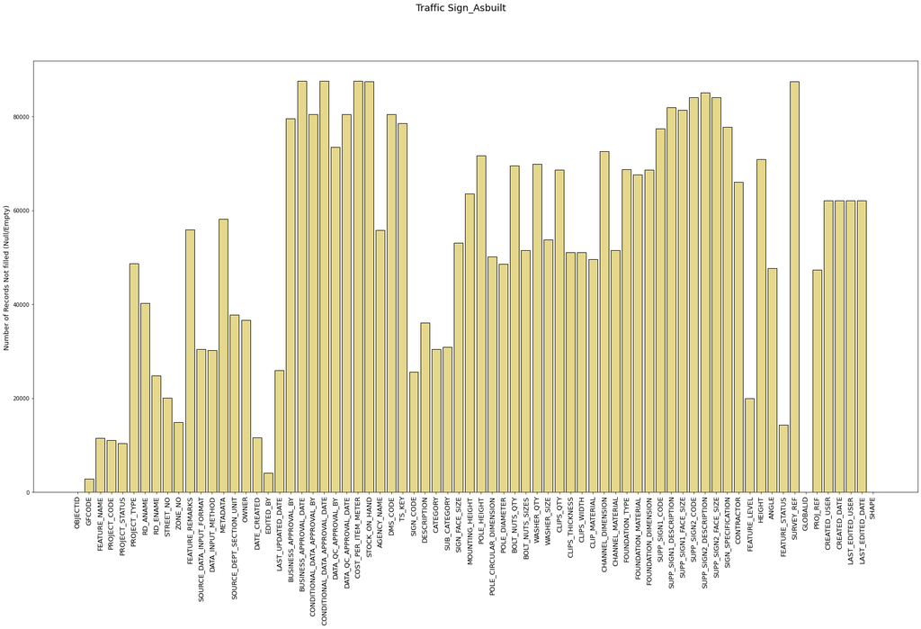

```python
x = Traffic_Sign.columns
y = Traffic_Sign.isnull().sum()
plt.figure(figsize=(30,15))
plt.bar(x, y, color= (0.8,0.7,0.1,0.5),  edgecolor='Black')
plt.suptitle("Traffic Sign_Asbuilt", fontsize=18)
plt.ylabel("Number of Records Not filled (Null/Empty) ", fontsize=13)
plt.xticks(rotation=90, fontsize=13)
plt.show()
```

### 4. Traffic Signal Pole

Traffic Signal Pole feature class has:

```
    •   Attribute Fields (Columns): 76
    •   Total Records (Rows): 2,174
```

```python
Traffic_Signal_Pole = pd.DataFrame.spatial.from_featureclass(r"C:\Users\esd_kgathogo\AppData\Roaming\ESRI\Desktop10.7\ArcCatalog\PWAROADS.sde\SDE.TRAFFIC_SAFETY\SDE.TRAFFIC_SIGNAL_POLE")
Traffic_Signal_Pole.head(2)
```

|  | OBJECTID | GFCODE | FEATURE_NAME | PROJECT_CODE | PROJECT_STATUS | PROJECT_TYPE | RD_ANAME | RD_ENAME | STREET_NO | ZONE_NO | FEATURE_REMARKS | SOURCE_DATA_INPUT_FORMAT | DATA_INPUT_METHOD | METADATA | SOURCE_DEPT_SECTION_UNIT | OWNER | DATE_CREATED | EDITED_BY | LAST_UPDATED_DATE | BUSINESS_APPROVAL_BY | BUSINESS_APPROVAL_DATE | CONDITIONAL_DATA_APPROVAL_BY | CONDITIONAL_DATA_APPROVAL_DATE | DATA_QC_APPROVAL_BY | DATA_QC_APPROVAL_DATE | COST_PER_ITEM_METER | STOCK_ON_HAND | AGENCY_NAME | DMS_CODE | … |
| --- | --- | --- | --- | --- | --- | --- | --- | --- | --- | --- | --- | --- | --- | --- | --- | --- | --- | --- | --- | --- | --- | --- | --- | --- | --- | --- | --- | --- | --- | --- |
| 0 | 7434 | RDNDSNPL | Traffic Signal Pole | IA 14/15 C 035 G | As Built | RIW | الطرفة | Al Tarfa | 800.0 | 30.0 | Gantry | DWG | Data Conversion | Yes | Roads Projects | O&M Roads | 2020-01-11 | AJM | 2020-01-11 | N/A | None | N/A | None | N/A | NaT | None | None | Ashghal | N/A | … |
| 1 | 7431 | RDNDSNPL | Traffic Signal Pole | IA 14/15 C 035 G | As Built | RIW | الطرفة | Al Tarfa | 800.0 | 30.0 | None | DWG | Data Conversion | Yes | Roads Projects | O&M Roads | 2020-01-11 | AJM | 2020-01-11 | N/A | None | N/A | None | N/A | NaT | None | None | Ashghal | N/A | … |

```python
Traffic_Signal_Pole.shape
```

```
(3257, 76)
```

```python
Traffic_Signal_Pole_null = pd.DataFrame(Traffic_Signal_Pole.isnull().sum())
Traffic_Signal_Pole_null
```

|  | 0 |
| --- | --- |
| OBJECTID | 0 |
| GFCODE | 0 |
| FEATURE_NAME | 205 |
| PROJECT_CODE | 311 |
| PROJECT_STATUS | 330 |
| ... | ... |
| CREATED_USER | 2919 |
| CREATED_DATE | 2919 |
| LAST_EDITED_USER | 2919 |
| LAST_EDITED_DATE | 2919 |
| SHAPE | 0 |

76 rows × 1 columns

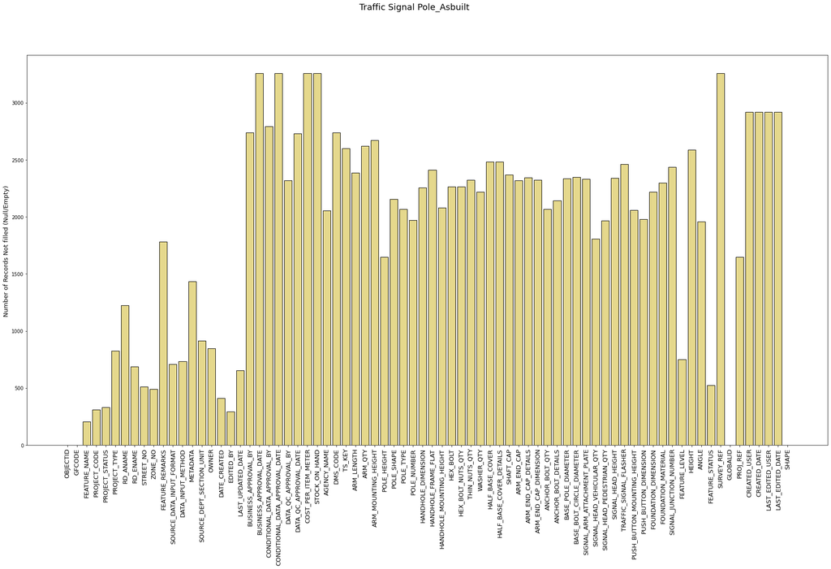

```python
x = Traffic_Signal_Pole.columns
y = Traffic_Signal_Pole.isnull().sum()
plt.figure(figsize=(30,15))
plt.bar(x, y, color= (0.8,0.7,0.1,0.5),  edgecolor='Black')
plt.suptitle("Traffic Signal Pole_Asbuilt", fontsize=18)
plt.ylabel("Number of Records Not filled (Null/Empty) ", fontsize=13)
plt.xticks(rotation=90, fontsize=13)
plt.show()
```

### 5. Signal Duct

Signal Duct feature class has:

```
    •   Attribute Fields (Columns): 53
    •   Total Records (Rows): 5,235
```

```python
Signal_Duct = pd.DataFrame.spatial.from_featureclass(r"C:\Users\esd_kgathogo\AppData\Roaming\ESRI\Desktop10.7\ArcCatalog\PWAROADS.sde\SDE.TRAFFIC_SAFETY\SDE.SIGNAL_DUCT")
Signal_Duct.head(2)
```

|  | OBJECTID | GFCODE | FEATURE_NAME | PROJECT_CODE | PROJECT_STATUS | PROJECT_TYPE | RD_ANAME | RD_ENAME | STREET_NO | ZONE_NO | FEATURE_REMARKS | SOURCE_DATA_INPUT_FORMAT | DATA_INPUT_METHOD | METADATA | SOURCE_DEPT_SECTION_UNIT | OWNER | DATE_CREATED | EDITED_BY | LAST_UPDATED_DATE | BUSINESS_APPROVAL_BY | BUSINESS_APPROVAL_DATE | CONDITIONAL_DATA_APPROVAL_BY | CONDITIONAL_DATA_APPROVAL_DATE | DATA_QC_APPROVAL_BY | DATA_QC_APPROVAL_DATE | COST_PER_ITEM_METER | STOCK_ON_HAND | AGENCY_NAME | DMS_CODE | … |
| --- | --- | --- | --- | --- | --- | --- | --- | --- | --- | --- | --- | --- | --- | --- | --- | --- | --- | --- | --- | --- | --- | --- | --- | --- | --- | --- | --- | --- | --- | --- |
| 0 | 4677 | RDARSNDT | Traffic Signal Duct | AMA 10-11 M 009 G | As Built yet to be Approved | RIW | القلعة | Al Qalah | 910.0 | 53.0 | None | DWG | Data Conversion | None | None | None | 2018-12-30 | Gelie | 2018-12-31 | None | None | None | None | None | NaT | None | None | None | None | … |
| 1 | 4674 | RDARSNDT | Traffic Signal Duct | AMA 10-11 M 009 G | As Built yet to be Approved | RIW | القلعة | Al Qalah | 910.0 | 53.0 | None | DWG | Data Conversion | None | None | None | 2018-12-30 | Gelie | 2018-12-31 | None | None | None | None | None | NaT | None | None | None | None | … |

```python
Signal_Duct.shape
```

```
(6674, 53)
```

```python
Signal_Duct_null = pd.DataFrame(Signal_Duct.isnull().sum())
Signal_Duct_null
```

|  | 0 |
| --- | --- |
| OBJECTID | 0 |
| GFCODE | 0 |
| FEATURE_NAME | 283 |
| PROJECT_CODE | 0 |
| PROJECT_STATUS | 0 |
| PROJECT_TYPE | 1095 |
| RD_ANAME | 1721 |
| RD_ENAME | 640 |
| STREET_NO | 309 |
| ZONE_NO | 259 |
| FEATURE_REMARKS | 3517 |
| SOURCE_DATA_INPUT_FORMAT | 985 |
| DATA_INPUT_METHOD | 985 |
| METADATA | 2270 |
| SOURCE_DEPT_SECTION_UNIT | 331 |
| OWNER | 1865 |
| DATE_CREATED | 139 |
| EDITED_BY | 0 |
| LAST_UPDATED_DATE | 1190 |
| BUSINESS_APPROVAL_BY | 5359 |
| BUSINESS_APPROVAL_DATE | 6674 |
| CONDITIONAL_DATA_APPROVAL_BY | 5142 |
| CONDITIONAL_DATA_APPROVAL_DATE | 6674 |
| DATA_QC_APPROVAL_BY | 3779 |
| DATA_QC_APPROVAL_DATE | 5141 |
| COST_PER_ITEM_METER | 6674 |
| STOCK_ON_HAND | 6674 |
| AGENCY_NAME | 4090 |
| DMS_CODE | 5142 |
| DUCT_TYPE | 585 |
| DIAMETER | 1834 |
| DUCT_QUANTITY | 2823 |
| DUCT_WAY | 1242 |
| CABLE_1_QTY | 4585 |
| CABLE_2_QTY | 5293 |
| CABLE_3_QTY | 5694 |
| CABLE_4_QTY | 6057 |
| CABLE_5_QTY | 6164 |
| CONTRACTOR | 3086 |
| FEATURE_LEVEL | 1023 |
| DEPTH | 4460 |
| FEATURE_STATUS | 2718 |
| SURVEY_REF | 6674 |
| GLOBALID | 0 |
| PROJ_REF | 4142 |
| CREATED_USER | 6674 |
| CREATED_DATE | 6674 |
| LAST_EDITED_USER | 6674 |
| LAST_EDITED_DATE | 6674 |
| JUNCTION_NUMBER | 6457 |
| SHAPE.AREA | 0 |
| SHAPE.LEN | 0 |
| SHAPE | 0 |

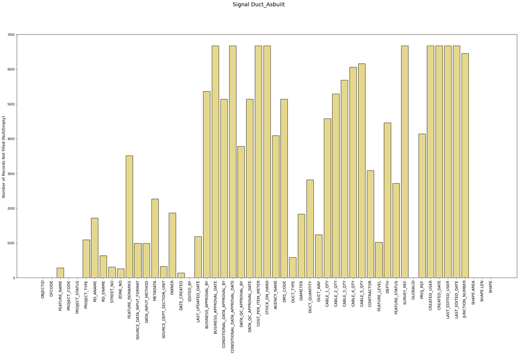

```python
x = Signal_Duct.columns
y = Signal_Duct.isnull().sum()
plt.figure(figsize=(30,15))
plt.bar(x, y, color= (0.8,0.7,0.1,0.5),  edgecolor='Black')
plt.suptitle("Signal Duct_Asbuilt", fontsize=18)
plt.ylabel("Number of Records Not filled (Null/Empty) ", fontsize=13)
plt.xticks(rotation=90, fontsize=13)
plt.show()
```

### 6. Control Box

Control Box feature class has:

```
    •   Attribute Fields (Columns): 51
    •   Total Records (Rows): 209
```

```python
Control_Box = pd.DataFrame.spatial.from_featureclass(r"C:\Users\esd_kgathogo\AppData\Roaming\ESRI\Desktop10.7\ArcCatalog\PWAROADS.sde\SDE.TRAFFIC_SAFETY\SDE.Control_Box")
Control_Box.head(2)
```

|  | OBJECTID | GFCODE | FEATURE_NAME | PROJECT_CODE | PROJECT_STATUS | PROJECT_TYPE | RD_ANAME | RD_ENAME | STREET_NO | ZONE_NO | FEATURE_REMARKS | SOURCE_DATA_INPUT_FORMAT | DATA_INPUT_METHOD | METADATA | SOURCE_DEPT_SECTION_UNIT | OWNER | DATE_CREATED | EDITED_BY | LAST_UPDATED_DATE | BUSINESS_APPROVAL_BY | BUSINESS_APPROVAL_DATE | CONDITIONAL_DATA_APPROVAL_BY | CONDITIONAL_DATA_APPROVAL_DATE | DATA_QC_APPROVAL_BY | DATA_QC_APPROVAL_DATE | COST_PER_ITEM_METER | STOCK_ON_HAND | AGENCY_NAME | DMS_CODE | … |
| --- | --- | --- | --- | --- | --- | --- | --- | --- | --- | --- | --- | --- | --- | --- | --- | --- | --- | --- | --- | --- | --- | --- | --- | --- | --- | --- | --- | --- | --- | --- |
| 0 | 67 | RDNDCTBX | Control Box | ERC0725C5 | As Built | None | ام بركة | North Area | 75.0 | 100.0 | None | DWG | Data Conversion | None | PDS | None | 2014-09-16 | Arif | NaT | None | None | None | None | None | NaT | None | None | None | None | … |
| 1 | 68 | RDNDCTBX | Control Box | ERC0725C5 | As Built | None | ام بركة | North Area | 75.0 | 100.0 | None | DWG | Data Conversion | None | PDS | None | 2014-09-16 | Arif | NaT | None | None | None | None | None | NaT | None | None | None | None | … |

```python
Control_Box.shape
```

```
(223, 51)
```

```python
Control_Box_null = pd.DataFrame(Control_Box.isnull().sum())
Control_Box_null
```

|  | 0 |
| --- | --- |
| OBJECTID | 0 |
| GFCODE | 0 |
| FEATURE_NAME | 2 |
| PROJECT_CODE | 1 |
| PROJECT_STATUS | 1 |
| PROJECT_TYPE | 58 |
| RD_ANAME | 98 |
| RD_ENAME | 70 |
| STREET_NO | 62 |
| ZONE_NO | 60 |
| FEATURE_REMARKS | 121 |
| SOURCE_DATA_INPUT_FORMAT | 37 |
| DATA_INPUT_METHOD | 37 |
| METADATA | 91 |
| SOURCE_DEPT_SECTION_UNIT | 48 |
| OWNER | 62 |
| DATE_CREATED | 4 |
| EDITED_BY | 1 |
| LAST_UPDATED_DATE | 66 |
| BUSINESS_APPROVAL_BY | 213 |
| BUSINESS_APPROVAL_DATE | 223 |
| CONDITIONAL_DATA_APPROVAL_BY | 213 |
| CONDITIONAL_DATA_APPROVAL_DATE | 223 |
| DATA_QC_APPROVAL_BY | 180 |
| DATA_QC_APPROVAL_DATE | 186 |
| COST_PER_ITEM_METER | 223 |
| STOCK_ON_HAND | 223 |
| AGENCY_NAME | 124 |
| DMS_CODE | 161 |
| FEATURE_LEVEL | 35 |
| HEIGHT | 198 |
| MATERIAL | 112 |
| DIMENSIONS | 111 |
| CONTROL_BOX_SIZE | 130 |
| CONTROL_BOX_SHAPE | 114 |
| OPERATION_TYPE | 196 |
| LOCATION | 191 |
| VOLTAGE | 129 |
| SIGNAL_ID_CONNECTED | 206 |
| JUNCTION_NAME | 178 |
| MANUFACTURER | 140 |
| FEATURE_STATUS | 62 |
| SURVEY_REF | 223 |
| GLOBALID | 0 |
| PROJ_REF | 143 |
| CREATED_USER | 223 |
| CREATED_DATE | 223 |
| LAST_EDITED_USER | 223 |
| LAST_EDITED_DATE | 223 |
| JUNCTION_NUMBER | 223 |
| SHAPE | 0 |

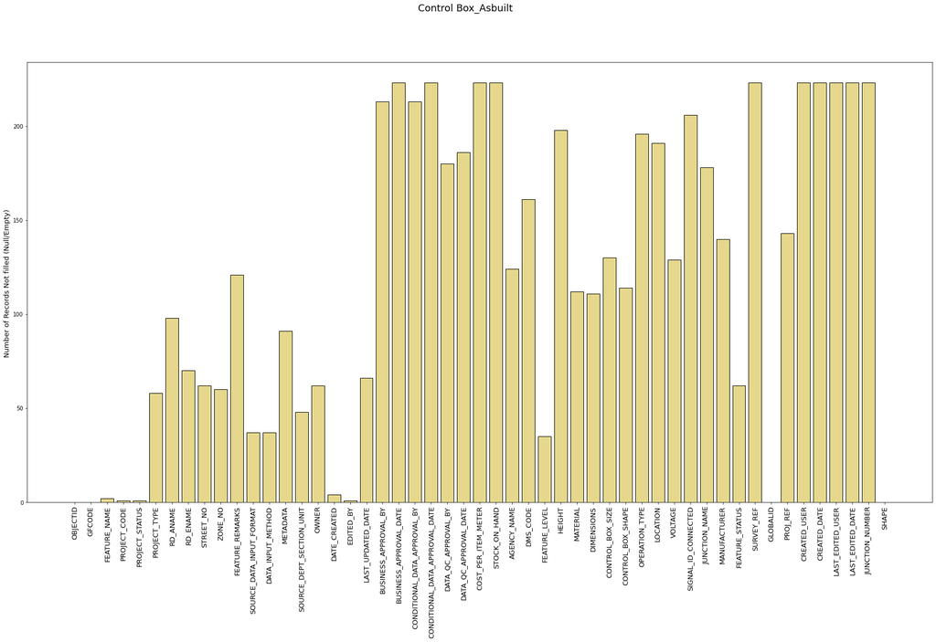

```python
x = Control_Box.columns
y = Control_Box.isnull().sum()
plt.figure(figsize=(30,15))
plt.bar(x, y, color= (0.8,0.7,0.1,0.5),  edgecolor='Black')
plt.suptitle("Control Box_Asbuilt", fontsize=18)
plt.ylabel("Number of Records Not filled (Null/Empty) ", fontsize=13)
plt.xticks(rotation=90, fontsize=13)
plt.show()
```

### 7. Detector Loop

Detector Loop feature class has:

```
    •   Attribute Fields (Columns): 51
    •   Total Records (Rows): 7,114
```

```python
Detector_Loop = pd.DataFrame.spatial.from_featureclass(r"C:\Users\esd_kgathogo\AppData\Roaming\ESRI\Desktop10.7\ArcCatalog\PWAROADS.sde\SDE.TRAFFIC_SAFETY\SDE.Detector_Loop")
Detector_Loop.head(2)
```

|  | OBJECTID | GFCODE | FEATURE_NAME | PROJECT_CODE | PROJECT_STATUS | PROJECT_TYPE | RD_ANAME | RD_ENAME | STREET_NO | ZONE_NO | FEATURE_REMARKS | SOURCE_DATA_INPUT_FORMAT | DATA_INPUT_METHOD | METADATA | SOURCE_DEPT_SECTION_UNIT | OWNER | DATE_CREATED | EDITED_BY | LAST_UPDATED_DATE | BUSINESS_APPROVAL_BY | BUSINESS_APPROVAL_DATE | CONDITIONAL_DATA_APPROVAL_BY | CONDITIONAL_DATA_APPROVAL_DATE | DATA_QC_APPROVAL_BY | DATA_QC_APPROVAL_DATE | COST_PER_ITEM_METER | STOCK_ON_HAND | AGENCY_NAME | DMS_CODE | … |
| --- | --- | --- | --- | --- | --- | --- | --- | --- | --- | --- | --- | --- | --- | --- | --- | --- | --- | --- | --- | --- | --- | --- | --- | --- | --- | --- | --- | --- | --- | --- |
| 0 | 9539 | RDLNDTLP | None | RA 07/08 C16 G | As Built | RIW | الثمامة | Al Thumama | 830.0 | 46.0 | None | DWG | Data Conversion | No | PDS | O&M Roads | 2020-06-06 15:17:07 | Eric | NaT | None | None | None | None | None | NaT | None | None | None | None | … |
| 1 | 9536 | RDLNDTLP | None | RA 07/08 C16 G | As Built | RIW | الثمامة | Al Thumama | 830.0 | 46.0 | None | DWG | Data Conversion | No | PDS | O&M Roads | 2020-06-06 15:17:07 | Eric | NaT | None | None | None | None | None | NaT | None | None | None | None | … |

```python
Detector_Loop.shape
```

```
(7123, 51)
```

```python
Detector_Loop_null = pd.DataFrame(Detector_Loop.isnull().sum())
```

```python
Detector_Loop_null.head(72)
```

|  | 0 |
| --- | --- |
| OBJECTID | 0 |
| GFCODE | 0 |
| FEATURE_NAME | 31 |
| PROJECT_CODE | 0 |
| PROJECT_STATUS | 0 |
| PROJECT_TYPE | 2578 |
| RD_ANAME | 1673 |
| RD_ENAME | 452 |
| STREET_NO | 374 |
| ZONE_NO | 473 |
| FEATURE_REMARKS | 6050 |
| SOURCE_DATA_INPUT_FORMAT | 2250 |
| DATA_INPUT_METHOD | 2250 |
| METADATA | 3812 |
| SOURCE_DEPT_SECTION_UNIT | 621 |
| OWNER | 3359 |
| DATE_CREATED | 853 |
| EDITED_BY | 0 |
| LAST_UPDATED_DATE | 3228 |
| BUSINESS_APPROVAL_BY | 6321 |
| BUSINESS_APPROVAL_DATE | 7123 |
| CONDITIONAL_DATA_APPROVAL_BY | 6069 |
| CONDITIONAL_DATA_APPROVAL_DATE | 7123 |
| DATA_QC_APPROVAL_BY | 5815 |
| DATA_QC_APPROVAL_DATE | 6833 |
| COST_PER_ITEM_METER | 7123 |
| STOCK_ON_HAND | 7123 |
| AGENCY_NAME | 5239 |
| DMS_CODE | 6069 |
| TYPE | 5220 |
| MATERIAL | 5114 |
| OPERATING_VOLTAGE | 0 |
| TESTING_VOLTAGE | 116 |
| TEMPERATURE__RANGE | 1565 |
| PEAK_RESISTANCE | 116 |
| SHORT_CIRCUIT_TEMPERATURE | 116 |
| MINIMUM_BENDING_RADIUS | 106 |
| SPECIFICATIONS | 3510 |
| FEATURE_LEVEL | 2420 |
| DEPTH | 5300 |
| FEATURE_STATUS | 1480 |
| SURVEY_REF | 7123 |
| GLOBALID | 0 |
| PROJ_REF | 5784 |
| CREATED_USER | 7123 |
| CREATED_DATE | 7123 |
| LAST_EDITED_USER | 7123 |
| LAST_EDITED_DATE | 7123 |
| JUNCTION_NUMBER | 7113 |
| SHAPE.LEN | 0 |
| SHAPE | 2 |

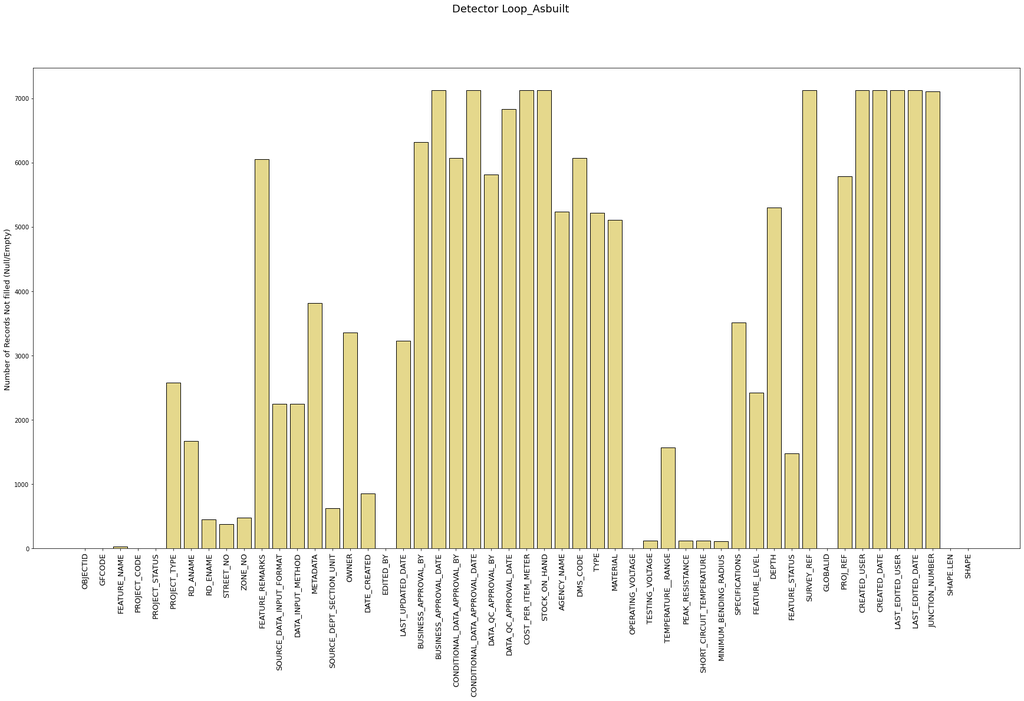

```python
x = Detector_Loop.columns
y = Detector_Loop.isnull().sum()
plt.figure(figsize=(30,15))
plt.bar(x, y, color= (0.8,0.7,0.1,0.5),  edgecolor='Black')
plt.suptitle("Detector Loop_Asbuilt", fontsize=18)
plt.ylabel("Number of Records Not filled (Null/Empty) ", fontsize=13)
plt.xticks(rotation=90, fontsize=13)
plt.show()
```

### 8. Inspection Chamber

Inspection Chamber feature class has:

```
    •   Attribute Fields (Columns): 47
    •   Total Records (Rows): 3,201
```

```python
Inspection_Chamber = pd.DataFrame.spatial.from_featureclass(r"C:\Users\esd_kgathogo\AppData\Roaming\ESRI\Desktop10.7\ArcCatalog\PWAROADS.sde\SDE.TRAFFIC_SAFETY\SDE.INSPECTION_CHAMBER")
Inspection_Chamber.head(2)
```

|  | OBJECTID | GFCODE | FEATURE_NAME | PROJECT_CODE | PROJECT_STATUS | PROJECT_TYPE | RD_ANAME | RD_ENAME | STREET_NO | ZONE_NO | FEATURE_REMARKS | SOURCE_DATA_INPUT_FORMAT | DATA_INPUT_METHOD | METADATA | SOURCE_DEPT_SECTION_UNIT | OWNER | DATE_CREATED | EDITED_BY | LAST_UPDATED_DATE | BUSINESS_APPROVAL_BY | BUSINESS_APPROVAL_DATE | CONDITIONAL_DATA_APPROVAL_BY | CONDITIONAL_DATA_APPROVAL_DATE | DATA_QC_APPROVAL_BY | DATA_QC_APPROVAL_DATE | COST_PER_ITEM_METER | STOCK_ON_HAND | AGENCY_NAME | DMS_CODE | … |
| --- | --- | --- | --- | --- | --- | --- | --- | --- | --- | --- | --- | --- | --- | --- | --- | --- | --- | --- | --- | --- | --- | --- | --- | --- | --- | --- | --- | --- | --- | --- |
| 0 | 5754 | RDARINCH | Inspection Chamber | RA09-10C085G | As Built yet to be Approved | RIW | السد | Al Sadd | 343.0 | 38.0 | None | DWG | Data Conversion | None | None | None | 2019-01-01 | Gelie | 2019-01-06 | None | None | None | None | None | NaT | None | None | None | None | … |
| 1 | 5751 | RDARINCH | Inspection Chamber | RA09-10C085G | As Built yet to be Approved | RIW | السد | Al Sadd | 343.0 | 39.0 | None | DWG | Data Conversion | None | None | None | 2019-01-01 | Gelie | 2019-01-06 | None | None | None | None | None | NaT | None | None | None | None | … |

```python
Inspection_Chamber.shape
```

```
(3877, 47)
```

```python
Inspection_Chamber_null = pd.DataFrame(Inspection_Chamber.isnull().sum())
```

```python
Inspection_Chamber_null
```

|  | 0 |
| --- | --- |
| OBJECTID | 0 |
| GFCODE | 0 |
| FEATURE_NAME | 52 |
| PROJECT_CODE | 0 |
| PROJECT_STATUS | 0 |
| PROJECT_TYPE | 782 |
| RD_ANAME | 1028 |
| RD_ENAME | 349 |
| STREET_NO | 262 |
| ZONE_NO | 308 |
| FEATURE_REMARKS | 1915 |
| SOURCE_DATA_INPUT_FORMAT | 651 |
| DATA_INPUT_METHOD | 651 |
| METADATA | 1658 |
| SOURCE_DEPT_SECTION_UNIT | 366 |
| OWNER | 1274 |
| DATE_CREATED | 0 |
| EDITED_BY | 0 |
| LAST_UPDATED_DATE | 837 |
| BUSINESS_APPROVAL_BY | 3714 |
| BUSINESS_APPROVAL_DATE | 3877 |
| CONDITIONAL_DATA_APPROVAL_BY | 3714 |
| CONDITIONAL_DATA_APPROVAL_DATE | 3877 |
| DATA_QC_APPROVAL_BY | 3056 |
| DATA_QC_APPROVAL_DATE | 3146 |
| COST_PER_ITEM_METER | 3877 |
| STOCK_ON_HAND | 3877 |
| AGENCY_NAME | 2550 |
| DMS_CODE | 3175 |
| CHAMBER_TYPE | 511 |
| DIMENSION | 1186 |
| MATERIAL | 1686 |
| CONTRACTOR | 1935 |
| FEATURE_LEVEL | 744 |
| DEPTH | 2684 |
| FEATURE_STATUS | 859 |
| SURVEY_REF | 3877 |
| GLOBALID | 0 |
| PROJ_REF | 2414 |
| CREATED_USER | 3877 |
| CREATED_DATE | 3877 |
| LAST_EDITED_USER | 3877 |
| LAST_EDITED_DATE | 3877 |
| JUNCTION_NUMBER | 3877 |
| SHAPE.AREA | 0 |
| SHAPE.LEN | 0 |
| SHAPE | 0 |

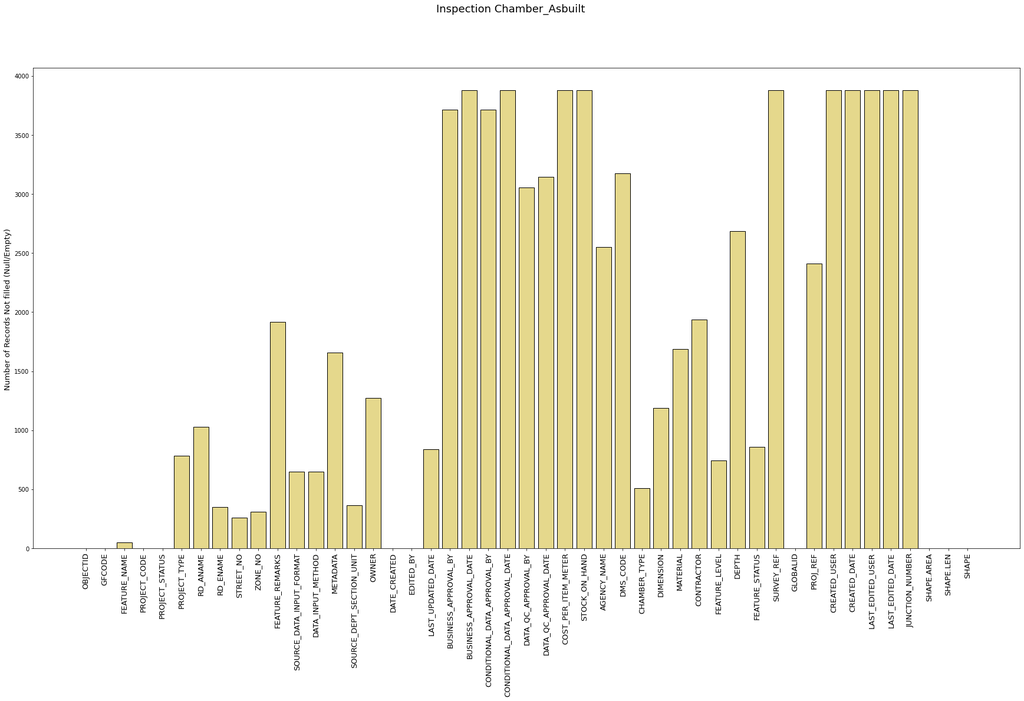

```python
x = Inspection_Chamber.columns
y = Inspection_Chamber.isnull().sum()
plt.figure(figsize=(30,15))
plt.bar(x, y, color= (0.8,0.7,0.1,0.5),  edgecolor='Black')
plt.suptitle("Inspection Chamber_Asbuilt", fontsize=18)
plt.ylabel("Number of Records Not filled (Null/Empty) ", fontsize=13)
plt.xticks(rotation=90, fontsize=13)
plt.show()
```

### 9. Phasing

Phasing feature class has:

```
    •   Attribute Fields (Columns): 46
    •   Total Records (Rows): 208
```

```python
Phasing = pd.DataFrame.spatial.from_featureclass(r"C:\Users\esd_kgathogo\AppData\Roaming\ESRI\Desktop10.7\ArcCatalog\PWAROADS.sde\SDE.TRAFFIC_SAFETY\SDE.PHASING")
Phasing.head(2)
```

|  | OBJECTID | GFCODE | FEATURE_NAME | PROJECT_CODE | PROJECT_STATUS | RD_ANAME | RD_ENAME | STREET_NO | ZONE_NO | FEATURE_REMARKS | SOURCE_DATA_INPUT_FORMAT | DATA_INPUT_METHOD | METADATA | SOURCE_DEPT_SECTION_UNIT | OWNER | DATE_CREATED | EDITED_BY | LAST_UPDATED_DATE | BUSINESS_APPROVAL_BY | BUSINESS_APPROVAL_DATE | CONDITIONAL_DATA_APPROVAL_BY | CONDITIONAL_DATA_APPROVAL_DATE | DATA_QC_APPROVAL_BY | DATA_QC_APPROVAL_DATE | COST_PER_ITEM_METER | STOCK_ON_HAND | AGENCY_NAME | DMS_CODE | PHASE_MODE | … |
| --- | --- | --- | --- | --- | --- | --- | --- | --- | --- | --- | --- | --- | --- | --- | --- | --- | --- | --- | --- | --- | --- | --- | --- | --- | --- | --- | --- | --- | --- | --- |
| 0 | 44 | None | Movement | ERC1400C4 | None | None | None | None | None | None | None | None | None | None | None | 2011-03-20 | Oumer | None | None | None | None | None | None | None | None | None | None | None | N/A | … |
| 1 | 45 | None | Movement | ERC1400C4 | None | None | None | None | None | None | None | None | None | None | None | 2011-03-20 | Oumer | None | None | None | None | None | None | None | None | None | None | None | N/A | … |

```python
Phasing.shape
```

```
(208, 46)
```

```python
Phasing_null = pd.DataFrame(Phasing.isnull().sum())
```

```python
Phasing_null
```

|  | 0 |
| --- | --- |
| OBJECTID | 0 |
| GFCODE | 208 |
| FEATURE_NAME | 0 |
| PROJECT_CODE | 8 |
| PROJECT_STATUS | 208 |
| RD_ANAME | 208 |
| RD_ENAME | 208 |
| STREET_NO | 208 |
| ZONE_NO | 208 |
| FEATURE_REMARKS | 208 |
| SOURCE_DATA_INPUT_FORMAT | 208 |
| DATA_INPUT_METHOD | 208 |
| METADATA | 208 |
| SOURCE_DEPT_SECTION_UNIT | 208 |
| OWNER | 208 |
| DATE_CREATED | 8 |
| EDITED_BY | 8 |
| LAST_UPDATED_DATE | 208 |
| BUSINESS_APPROVAL_BY | 208 |
| BUSINESS_APPROVAL_DATE | 208 |
| CONDITIONAL_DATA_APPROVAL_BY | 208 |
| CONDITIONAL_DATA_APPROVAL_DATE | 208 |
| DATA_QC_APPROVAL_BY | 208 |
| DATA_QC_APPROVAL_DATE | 208 |
| COST_PER_ITEM_METER | 208 |
| STOCK_ON_HAND | 208 |
| AGENCY_NAME | 208 |
| DMS_CODE | 208 |
| PHASE_MODE | 8 |
| PHASE_TYPE | 8 |
| PHASE_CODE | 196 |
| SIGNAL_JUNCTION_NUMBER | 8 |
| INTERSECTION_NAME | 8 |
| LOCATION | 8 |
| PHASING_AREA | 116 |
| FEATURE_STATUS | 208 |
| PROJECT_TYPE | 208 |
| SURVEY_REF | 208 |
| GLOBALID | 0 |
| PROJ_REF | 208 |
| CREATED_USER | 208 |
| CREATED_DATE | 208 |
| LAST_EDITED_USER | 208 |
| LAST_EDITED_DATE | 208 |
| SHAPE.LEN | 0 |
| SHAPE | 0 |

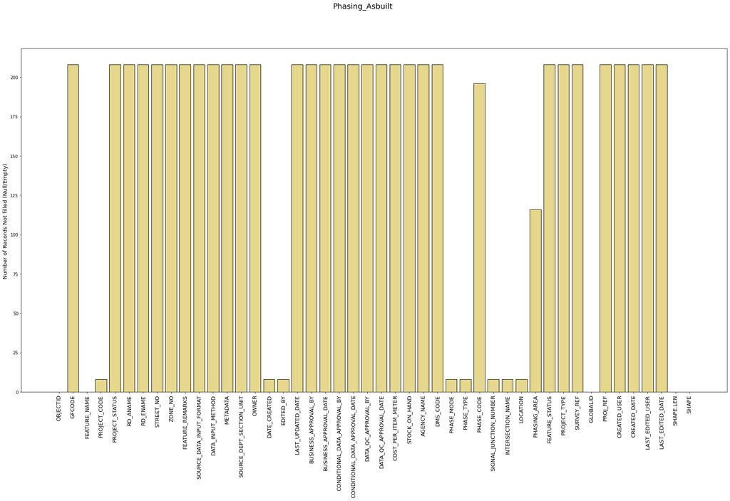

```python
x = Phasing.columns
y = Phasing.isnull().sum()
plt.figure(figsize=(30,15))
plt.bar(x, y, color= (0.8,0.7,0.1,0.5),  edgecolor='Black')
plt.suptitle("Phasing_Asbuilt", fontsize=18)
plt.ylabel("Number of Records Not filled (Null/Empty) ", fontsize=13)
plt.xticks(rotation=90, fontsize=13)
plt.show()
```

### 10. Studs

Studs feature class has:

```
    •   Attribute Fields (Columns): 56
    •   Total Records (Rows): 119,063
```

```python
Studs = pd.DataFrame.spatial.from_featureclass(r"C:\Users\esd_kgathogo\AppData\Roaming\ESRI\Desktop10.7\ArcCatalog\PWAROADS.sde\SDE.TRAFFIC_SAFETY\SDE.STUDS")
Studs.head(2)
```

|  | OBJECTID | GFCODE | FEATURE_NAME | PROJECT_CODE | PROJECT_STATUS | PROJECT_TYPE | RD_ANAME | RD_ENAME | STREET_NO | ZONE_NO | FEATURE_REMARKS | SOURCE_DATA_INPUT_FORMAT | DATA_INPUT_METHOD | METADATA | SOURCE_DEPT_SECTION_UNIT | OWNER | DATE_CREATED | EDITED_BY | LAST_UPDATED_DATE | BUSINESS_APPROVAL_BY | BUSINESS_APPROVAL_DATE | CONDITIONAL_DATA_APPROVAL_BY | CONDITIONAL_DATA_APPROVAL_DATE | DATA_QC_APPROVAL_BY | DATA_QC_APPROVAL_DATE | COST_PER_ITEM_METER | STOCK_ON_HAND | AGENCY_NAME | DMS_CODE | … |
| --- | --- | --- | --- | --- | --- | --- | --- | --- | --- | --- | --- | --- | --- | --- | --- | --- | --- | --- | --- | --- | --- | --- | --- | --- | --- | --- | --- | --- | --- | --- |
| 0 | 24514 | RDARRDMP | Road Studs | ERC0451C1 | Asbuilt | None | None | None | NaN | NaN | None | None | None | None | AsbuiltDwg | None | 2010-07-19 | Suresh | NaT | None | None | None | None | None | NaT | None | None | None | None | … |
| 1 | 24515 | RDARRDMP | Road Studs | ERC0451C1 | Asbuilt | None | None | None | NaN | NaN | None | None | None | None | AsbuiltDwg | None | 2010-07-19 | Suresh | NaT | None | None | None | None | None | NaT | None | None | None | None | … |

```python
Studs.shape
```

```
(118260, 56)
```

```python
Studs_null = pd.DataFrame(Studs.isnull().sum())
```

```python
Studs_null
```

|  | 0 |
| --- | --- |
| OBJECTID | 0 |
| GFCODE | 0 |
| FEATURE_NAME | 0 |
| PROJECT_CODE | 0 |
| PROJECT_STATUS | 0 |
| PROJECT_TYPE | 92935 |
| RD_ANAME | 78806 |
| RD_ENAME | 78806 |
| STREET_NO | 73627 |
| ZONE_NO | 72640 |
| FEATURE_REMARKS | 98740 |
| SOURCE_DATA_INPUT_FORMAT | 89721 |
| DATA_INPUT_METHOD | 89681 |
| METADATA | 91859 |
| SOURCE_DEPT_SECTION_UNIT | 21790 |
| OWNER | 101669 |
| DATE_CREATED | 0 |
| EDITED_BY | 0 |
| LAST_UPDATED_DATE | 96278 |
| BUSINESS_APPROVAL_BY | 116555 |
| BUSINESS_APPROVAL_DATE | 118260 |
| CONDITIONAL_DATA_APPROVAL_BY | 116555 |
| CONDITIONAL_DATA_APPROVAL_DATE | 118260 |
| DATA_QC_APPROVAL_BY | 113229 |
| DATA_QC_APPROVAL_DATE | 114107 |
| COST_PER_ITEM_METER | 118260 |
| STOCK_ON_HAND | 118260 |
| AGENCY_NAME | 114348 |
| DMS_CODE | 116555 |
| STUDS_TYPE | 65659 |
| STUDS_SHAPE | 103184 |
| STUDS_MATERIAL | 111463 |
| DIMENSIONS | 111646 |
| REFLECTOR_MATERIAL | 112781 |
| REFLECTOR_DIRECTION | 111442 |
| CARRIAGEWAY_SPACING | 99053 |
| STUDS_SPACE_DISTANCE | 112509 |
| BRAND_NAME | 113040 |
| MANUFACTURER | 113040 |
| WEIGHT | 117173 |
| COMPRESSIVE_STRENGTH | 113863 |
| STUDS_FIXING_TYPE | 112781 |
| FEATURE_LEVEL | 96358 |
| HEIGHT | 113591 |
| STUDS_CODE_COLOR | 80353 |
| USE_OF_STUDS | 80699 |
| NO_OF_REFLECTOR | 112802 |
| FEATURE_STATUS | 1849 |
| SURVEY_REF | 118260 |
| GLOBALID | 0 |
| PROJ_REF | 111877 |
| CREATED_USER | 118260 |
| CREATED_DATE | 118260 |
| LAST_EDITED_USER | 118260 |
| LAST_EDITED_DATE | 118260 |
| SHAPE | 0 |

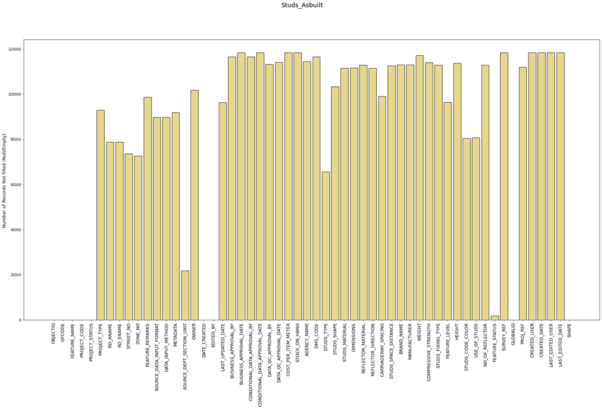

```python
x = Studs.columns
y = Studs.isnull().sum()
plt.figure(figsize=(30,15))
plt.bar(x, y, color= (0.8,0.7,0.1,0.5),  edgecolor='Black')
plt.suptitle("Studs_Asbuilt", fontsize=18)
plt.ylabel("Number of Records Not filled (Null/Empty) ", fontsize=13)
plt.xticks(rotation=90, fontsize=13)
plt.show()
```

### 11. Traffic junction RA

Traffic junction RA feature class has:

```
    •   Attribute Fields (Columns): 21
    •   Total Records (Rows): 1,048
```

```python
Traf_Junct_RA = pd.DataFrame.spatial.from_featureclass(r"C:\Users\esd_kgathogo\AppData\Roaming\ESRI\Desktop10.7\ArcCatalog\PWAROADS.sde\SDE.TRAFFIC_SAFETY\SDE.Traf_Junct_RA")
Traf_Junct_RA.head(2)
```

|  | OBJECTID_1 | OBJECTID | ANAME | ENAME | JUNCTION_T | CATEGORY | PREVIOUS_FEATURE | CURRENT_FEATURE | DBDATE | LASTUPDATE | STATUS | STATS | PROJECT_TYPE | GLOBALID | SURVEY_REF | EDITED_BY | CREATED_USER | CREATED_DATE | LAST_EDITED_USER | LAST_EDITED_DATE | SHAPE |
| --- | --- | --- | --- | --- | --- | --- | --- | --- | --- | --- | --- | --- | --- | --- | --- | --- | --- | --- | --- | --- | --- |
| 0 | 1 | 144.0 | تقاطع ابا الصليل | Aba Al Seleel Interchange | 7.0 | INTERCHANGE | None | None | 2012-11-15 | 2012-11-28 | Proposed | NaN | None | {3EF5A335-E9AE-4843-A14A-CA367D0EA322} | None | None | None | None | None | None | {"x": 225841.67279999983, "y": 379243.35029999... |
| 1 | 2 | 145.0 | تقاطع جري مصبح | Jery Musabbeh Interchange | 7.0 | INTERCHANGE | None | None | NaT | 2012-11-28 | Proposed | NaN | None | {C99E3141-4C0C-4AA0-90DC-1F8CF473AE9A} | None | None | None | None | None | None | {"x": 232774.19159999955, "y": 383505.20130000... |

```python
Traf_Junct_RA.shape
```

```
(1048, 21)
```

```python
Traf_Junct_RA_null = pd.DataFrame(Traf_Junct_RA.isnull().sum())
```

```python
Traf_Junct_RA_null
```

|  | 0 |
| --- | --- |
| OBJECTID_1 | 0 |
| OBJECTID | 866 |
| ANAME | 699 |
| ENAME | 699 |
| JUNCTION_T | 861 |
| CATEGORY | 108 |
| PREVIOUS_FEATURE | 1022 |
| CURRENT_FEATURE | 653 |
| DBDATE | 558 |
| LASTUPDATE | 260 |
| STATUS | 149 |
| STATS | 158 |
| PROJECT_TYPE | 1046 |
| GLOBALID | 0 |
| SURVEY_REF | 1048 |
| EDITED_BY | 1048 |
| CREATED_USER | 1048 |
| CREATED_DATE | 1048 |
| LAST_EDITED_USER | 1048 |
| LAST_EDITED_DATE | 1048 |
| SHAPE | 0 |

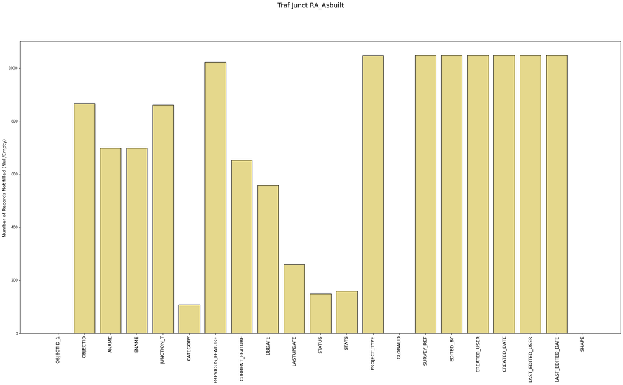

```python
x = Traf_Junct_RA.columns
y = Traf_Junct_RA.isnull().sum()
plt.figure(figsize=(30,15))
plt.bar(x, y, color= (0.8,0.7,0.1,0.5),  edgecolor='Black')
plt.suptitle("Traf Junct RA_Asbuilt", fontsize=18)
plt.ylabel("Number of Records Not filled (Null/Empty) ", fontsize=13)
plt.xticks(rotation=90, fontsize=13)
plt.show()
```